# Summarising data with Ethogram Plot

Quentin Geissmann

2 March 2016

## Aims

In this tutorial, we will learn how to:

- Summarise a behavioural variables per population
- Use grouping and facets
- Put error bars

## Going further than overview plots

In the previous tutorial, you learnt how to inspect data per animal. Often, you will want to complete that approach by computing averages of your variable of interest, per group and show statistical differences, at the *population* level.

The function `ethogramPlot` works very much like overview plots, but it makes averages of the variable of interest between animals, and represents the variable of interest on the y axis.

We use the same data as before:

```r
data(sleep_sexual_dimorphism)
dt <- sleep_sexual_dimorphism
```

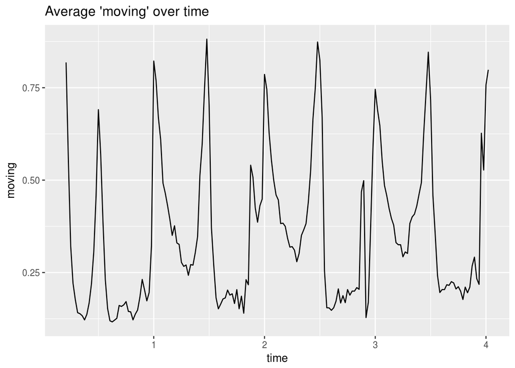

```r
pl <- ethogramPlot(moving, dt)
pl
```

Now the y axis is a value between 1 and 0 which represents the proportion time spent moving for the whole population of animals.

## Grouping and facets

This dataset contains males and females, so we want to compute one graph per sex:

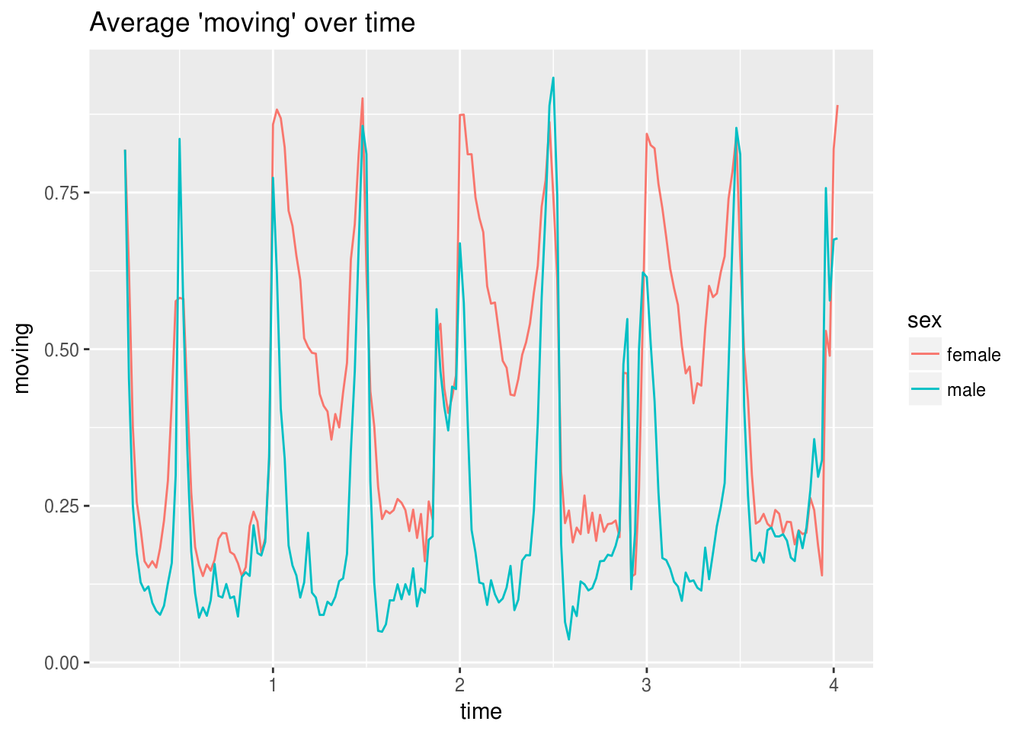

```r
pl <- ethogramPlot(moving, dt, sex)
pl
```

You an also use facets to separate groups:

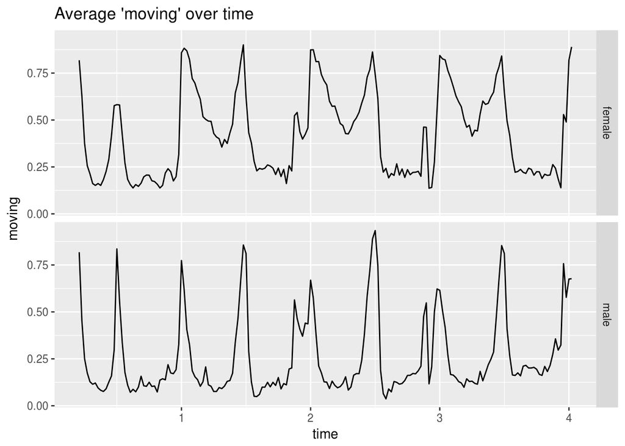

```r
pl <- ethogramPlot(moving, dt, facet_var=   sex)
pl
```

If you had two variables, say sex and genotype, you couls use a combinations of condition(grouping) and facets.

## Error bars

From this graphs, it is hard to get any idea of how significant the differences are. For this reason, we can compute error bars around the population average:

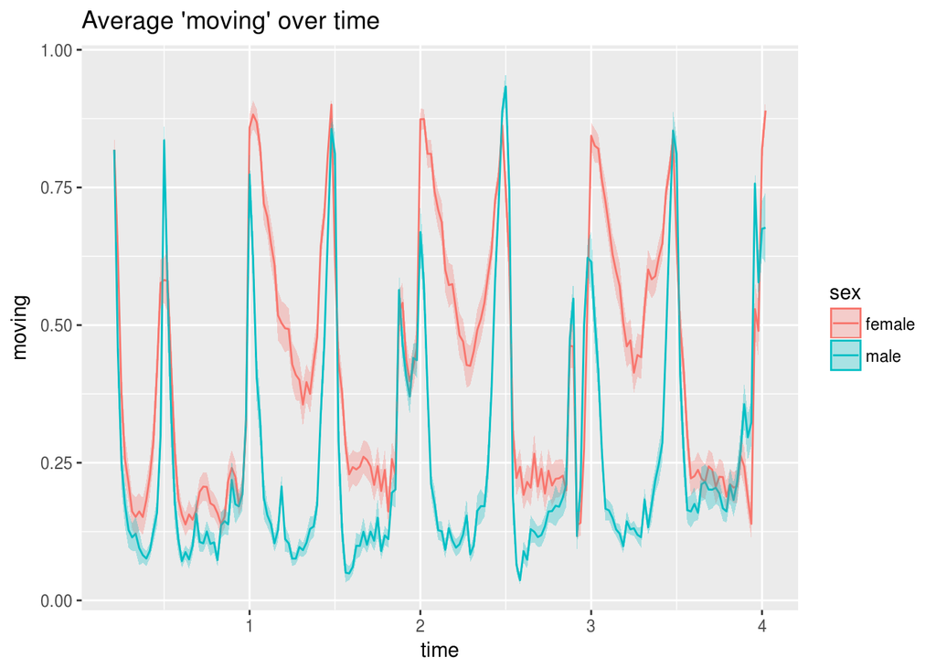

```r
pl <- ethogramPlot(moving, dt, sex, error_bar="sem")
pl
```

Here, I chose “`sem"`, which is common, you can also use `` "sd"` and ``”boot_ci“` bootstrap confidence interval. The latter takes longer to compute, but is more rigorous/assumption free.